# Introdução à Ciência de Dados

Mestrado em Administração  
Aula 12

Prof. Washington Santos da Silva

IFMG - Campus Formiga

28 de maio de 2026

## Nesta Aula

**Módulo: Fundamentos de Probabilidade e Simulação**

Esta é a quarta aula do módulo:

1. Fundamentos de probabilidade
2. Variáveis aleatórias e distribuições de probabilidade
3. Distribuições essenciais, simulação e ponte para inferência
4. **Aplicações de Teoria da Probabilidade em Finaças**

# Aplicações de Teoria da Probabilidade em Finaças

# Risco Financeiro

## Risco Financeiro

**Por que o risco importa?**

- O risco é fundamental em todas as decisões financeiras — desde negociações até regulamentação.
- No entanto, definir e mensurar o risco está longe de ser simples.
- Investidores, reguladores e acadêmicos frequentemente utilizam conceitos de risco diferentes.
- Esta seção explora o que é risco financeiro e como podemos começar a quantificá-lo.

## O Conceito de Risco Financeiro

**O que é Risco?**

- Não existe uma definição universal do que constitui risco
- Em termos gerais, o risco financeiro poderia ser definido como **“a probabilidade de perder parte ou a totalidade de um investimento”**
- Poderiam ser feitas inúmeras outras afirmações semelhantes, muitas das quais seriam contraditórias
- No contexto das instituições financeiras, uma definição formal é necessária, uma vez que a **gestão ativa de riscos** é uma de suas funções centrais.

## O Modelo de Média-Variância

**Resumo**

- Introduzido por Harry Markowitz (1952), o modelo de média-variância é uma estrutura fundamental para a seleção de portfólios.
- Os investidores buscam maximizar o retorno esperado para um determinado nível de risco ou minimizar o risco para um determinado nível de retorno.
- O risco é medido pela variância do portfólio: $\sigma^{2}_{portfolio} = w'Σw$
- O retorno é medido pela média do portfólio: $\mu_{portfolio} = w'\mu$
- O conjunto de portfólios ótimos forma a fronteira eficiente.

## O Modelo de Média-Variância

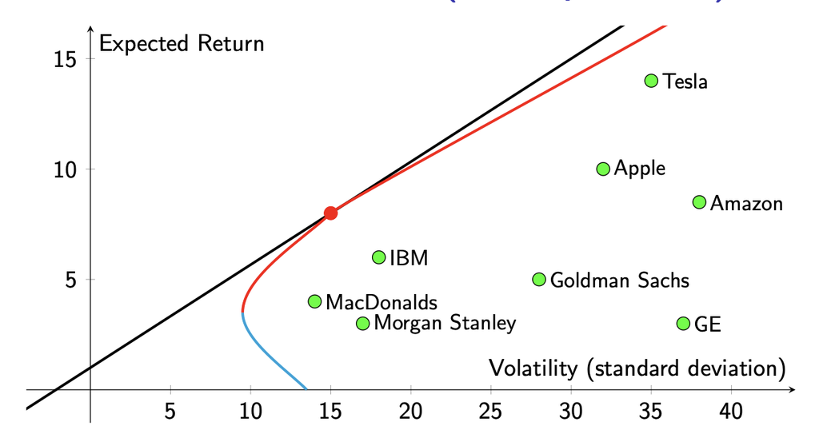

Figura 1: Fronteira eficiente.

## Qual ativo você prefere?

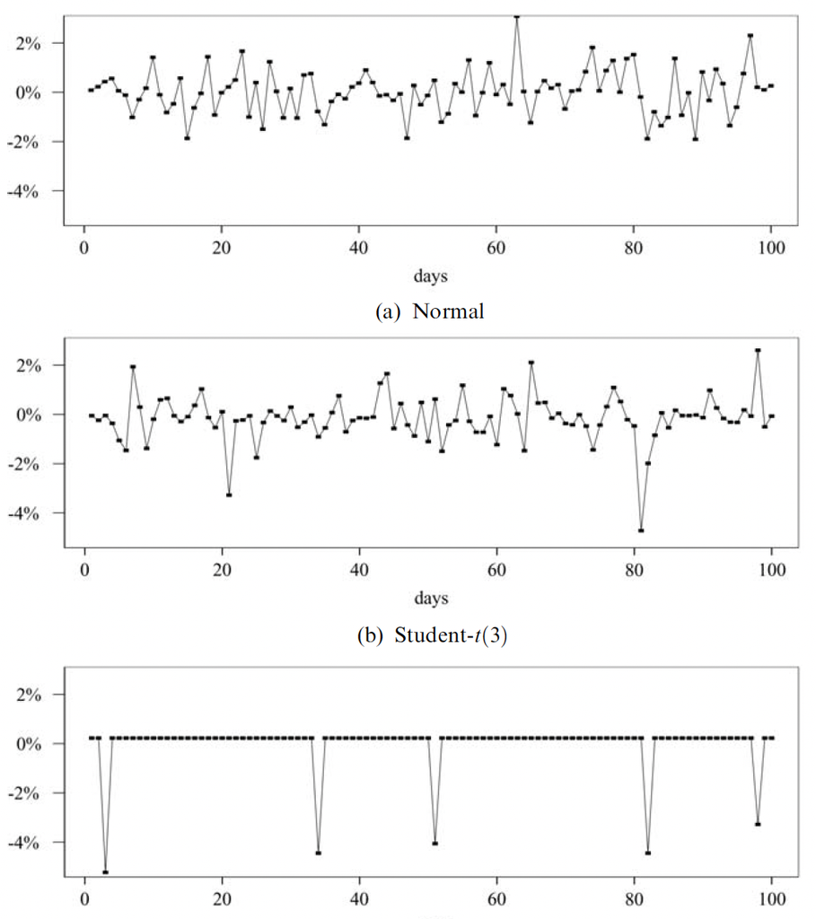

Figura 2: Todos os 3 ativos tem volatilidade igual a um e média zero.

## Qual ativo você prefere?

**Análise de média-variância**

- A **análise padrão de média-variância** indica que os três ativos são igualmente arriscados e preferíveis
- Como temos a mesma média $E(A) = E(B) = E(C) = 0$
- E a mesma volatilidade $\sigma_A = \sigma_B = \sigma_C = 1$
- Se usarmos a análise de média-variância, seremos **indiferentes entre os três**.

## Qual ativo é o preferido pela AMV?

**Análise de média-variância**

- Se, no entanto, perguntarmos a alguém qual ativo preferiria, provavelmente essa pessoa teria uma preferência pessoal por um deles.
- Um investidor que aplica o dinheiro de outra pessoa provavelmente preferirá $C$. **Por quê?**
- O ativo financeiro especulativo mais popular do mundo é o $C$ invertido – bilhetes de loteria.

## Então, o que aconteceu?

**Análise de média-variância**

- O modelo de média-variância vem com um conjunto de hipóteses que são benéficos para criar um modelo de investimento prático
- Mas, ao mesmo tempo, é inconsistente com a preferência de risco das pessoas
- Muitas vezes isso não é importante
- Mas às vezes é
- Lembre-se: “todos os modelos estão errados, alguns modelos são úteis”

## Nova situação

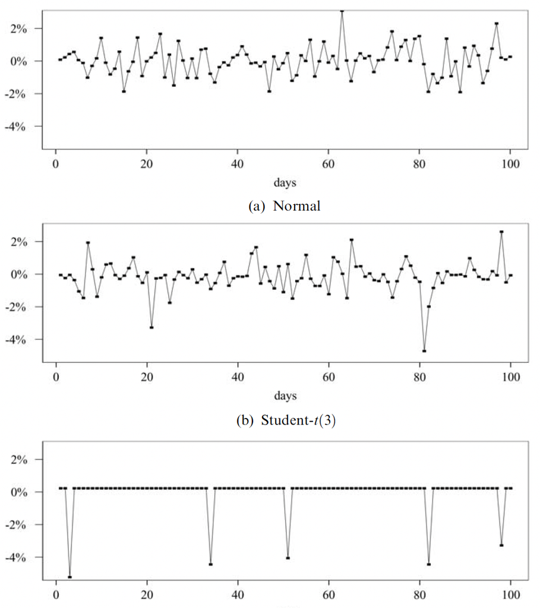

## Nova situação

**Agora, as preferências mudam**

- Porque os três ativos ainda têm a mesma volatilidade
- Mas como a média de $C$ é a mais alta, o modelo de média-variância nos diz para escolher $C$.
- No entanto, a maioria das pessoas escolheria um deles usando algum critério particular.

## Três opções de investimento

**Situação hipotética**

- Suponha que Ana, João e Maria tenham o mesmo valor disponível para investir
- Todos têm acesso à mesma tecnologia de investimento (todos fizeram um curso)
- Todos estão considerando investir $ 1 milhão na Amazon:
  - Ana é uma **day trader**, com o objetivo de comprar e vender dentro de uma semana
  - João é um **gestor de fundos**, e seus bônus dependem do desempenho trimestral
  - Maria tem 22 anos, planeja se aposentar em 40 anos e estima viver por mais 70 anos. Ela está poupando para sua **aposentadoria**.

## Suas escolhas

**Escolhas Distintas**

## Qual ativo é “melhor”?

**O problema da análise média-variância**

- **Não há forma óbvia** de discriminar entre os ativos A, B e C.
- Pode-se tentar **modelar a distribuição subjacente** dos preços de mercado e dos retornos, mas ela é geralmente desconhecida.
  - É possível estimá-la por métodos dev**Máxima Verossimilhança (MLE)**.
  - Ou testá-la contra outras distribuições com métodos como o teste de **Kolmogorov-Smirnov**.
- Na prática, é **impossível identificar com precisão** a distribuição dos retornos financeiros.

## Risco é uma Variável Latente

**Por que o risco exige modelagem estatística?**

- **Risco não é diretamente observável:** diferentemente da temperatura, medida por um termômetro;
- Risco deve ser **inferido** a partir dos preços de mercado observados.
- Por exemplo, no encerramento de um pregão, o retorno do dia é conhecido; enquanto o risco é desconhecido.
- Só podemos afirmar que o risco foi provavelmente elevado se os preços **oscilaram** muito.
- **Consequência:** medir risco requer **modelagem estatística**, o que implica necessariamente a adoção de hipóteses.
- **A solução mais comum:** empregar uma **medida de risco** — um único número que represente o risco de um ativo de forma comparável entre diferentes ativos e distribuições.

## Diferença sutil

**Medida de Risco (*Risk Measure*)**

- Uma medida de risco é um **método matemático** para calcular o risco.

**Medição de Risco (*Risk Measurement*)**

**Definição.** Um **número** que captura o risco. É obtido pela aplicação de dados a uma medida de risco.

## Volatilidade

**Descrição**

- **Definição:** a volatilidade (**desvio-padrão** dos retornos) é a principal medida de risco na análise financeira, estimada por:

$$s = \sqrt{\frac{1}{n-1}\sum_{i=1}^{n}(r_i - \bar{r})^2}$$

- **Condição de suficiência:** é uma medida adequada quando os retornos seguem distribuição normal — nesse caso, a **fronteira eficiente** da análise média-variância indica a melhor decisão de investimento.
- **O problema da não-normalidade:** se os retornos não são normalmente distribuídos, as soluções sobre a fronteira eficiente podem ser **ineficientes**.
- **Na prática:** a hipótese de normalidade é violada para a maioria — senão todos.
- **Consequência:** na maior parte das aplicações em risco financeiro, a volatilidade tende a **subestimar sistematicamente** o risco.

## Volatilidade

**Qual o próximo passo?**

- A volatilidade por si só não é suficiente para capturar o risco financeiro. Por quê?
- Agora, exploraremos medidas formais de risco: **Valor-em-Risco (VaR)** e **Perda Esperada (ES)**
- Essas medidas oferecem maneiras de quantificar o risco extremo e são usadas tanto na teoria quanto na regulamentação.

# Valor-em-Risco (VaR) e Perda Esperada (ES)

## Por que Valor-em-Risco (VaR)?

**Motivação**

- Investidores, gestores de risco e reguladores frequentemente precisam de uma medida resumida do risco de perdas relevantes de uma carteira.
- O **Valor-em-Risco** (*Value-at-Risk*, VaR) responde à pergunta:

> Em determinado horizonte de tempo, qual é o **limiar de perda** que deve ser ultrapassado apenas com pequena probabilidade?
- O VaR tornou-se amplamente usado em relatórios de risco, alocação de capital, limites de exposição e exigências regulatórias.
- Sua difusão nas instituições financeiras foi fortemente associada à iniciativa **RiskMetrics**, do JP Morgan, na década de 1990.

## Valor-em-Risco (VaR)

**Contexto histórico**

- Antes da popularização do VaR, a volatilidade e medidas de exposição, sensibilidade e limites de posição tinham papel central na mensuração de risco de mercado.
- O banco JP Morgan contribuiu para popularizar o **Valor-em-Risco (VaR)** e a metodologia **RiskMetrics**, baseada em médias móveis exponencialmente ponderadas.
- A adoção de modelos internos de risco também tinha implicações regulatórias, pois poderia afetar o capital requerido para cobrir risco de mercado.
- O relatório ficou conhecido como relatório das **16h15**, pois buscava produzir uma medida resumida do risco da instituição para a reunião diária de tesouraria.

## O Comitê de Basileia e o VaR

**Linha do tempo resumida**

- **Basileia I (1988):** foco inicial em risco de crédito e exigência de capital mínimo em relação aos ativos ponderados pelo risco.
- **Emenda de Risco de Mercado (1996):** incorporou requisitos de capital para risco de mercado e permitiu, sob critérios regulatórios, o uso de modelos internos.
- **Basileia II:** consolidou o arcabouço dos três pilares e manteve o VaR como referência importante na mensuração regulatória de risco de mercado.
- **Crise financeira de 2008:** evidenciou limitações de modelos baseados apenas em quantis, especialmente quando não capturam adequadamente a severidade das perdas na cauda.
- **FRTB:** no arcabouço revisado de risco de mercado, o **Expected Shortfall (ES)** substitui o VaR na abordagem de modelos internos.

## O que é o Valor-em-Risco (VaR)?

**Descrição informal**

- O **Valor-em-Risco** (*Value-at-Risk*, VaR) é uma medida de risco de cauda.
- Ele responde à seguinte pergunta:

> Em um dado horizonte de tempo, qual é o **limiar de perda** que só deve ser ultrapassado com uma pequena probabilidade?
- Por exemplo:
  - com $p = 0{,}01 = 1\%$, o VaR indica o limiar de perda que poderá ser **excedido** em aproximadamente **1% dos períodos**, em média;
  - com $p = 0{,}05 = 5\%$, o VaR indica o limiar de perda que poderá ser **excedido** em aproximadamente **5% dos períodos**, em média.
- Portanto, se uma carteira tem **VaR diário de R$ 10.000 a 1%**, isso significa que, segundo o modelo ou os dados utilizados, há aproximadamente **1% de probabilidade** de a perda diária ultrapassar R$ 10.000.

## O que é o Valor-em-Risco (VaR)?

**Atenção**

- O VaR **não é a perda máxima possível**.
- Ele é um **ponto de corte** da distribuição de perdas. Perdas maiores que o VaR ainda podem ocorrer, justamente com probabilidade aproximadamente igual a $p$.

## VaR e a distribuição dos retornos

**Retornos, perdas e quantis**

Em aplicações financeiras, normalmente observamos **retornos** de ativos ou carteiras.

Seja $R$ o retorno da carteira em certo horizonte de tempo. Quando $R < 0$, houve perda.

Para expressar perdas como valores positivos, definimos:

$$L = -R$$

Se $q_p(R)$ é o quantil inferior de ordem $p$ da distribuição dos retornos, então:

$$P(R \leq q_p(R)) = p$$

Como esse quantil costuma ser negativo, o VaR em proporção do valor da carteira é:

$$VaR_p = -q_p(R)$$

Para uma carteira com valor financeiro $V$, o VaR monetário é:

$$VaR_p^{\$} = -q_p(R) \times V$$

## VaR e a distribuição dos retornos

**Interpretação**

- O VaR é positivo porque está expresso como **perda**.
- Por exemplo, se o quantil de 1% dos retornos diários é $q_{0{,}01}(R) = -0{,}04$, então o VaR diário a 1% é de **4% do valor da carteira**.
- Isso significa que, segundo a distribuição usada, há aproximadamente **1% de probabilidade** de a perda diária ser superior a 4% do valor da carteira.

## Valor-em-Risco (VaR)

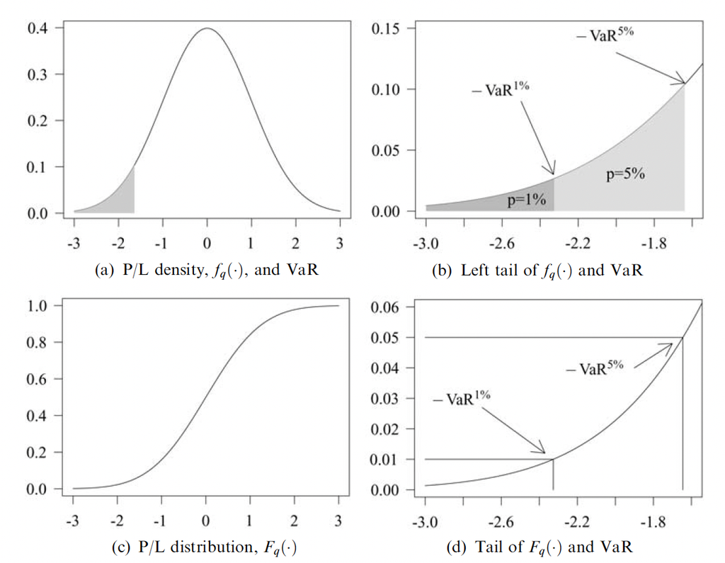

**a)** densidade $f_R(\cdot)$ dos retornos e VaR. **b)** cauda esquerda da $f_R(\cdot)$ e VaR. **c)** distribuição acumulada $F_R(\cdot)$ e VaR. **d)** cauda esquerda da $F_R(\cdot)$ e VaR.

## Valor-em-Risco (VaR)

**Três decisões no cálculo do VaR**

Para calcular o VaR, precisamos definir:

1. A **probabilidade de excedência**, $p$, isto é, a probabilidade de a perda ultrapassar o VaR.
2. O **horizonte de tempo**, isto é, o período ao longo do qual a perda será mensurada.
3. A forma de estimar a **distribuição dos retornos ou das perdas** da carteira.

## Valor-em-Risco (VaR)

**Qual probabilidade devemos usar?**

- Níveis de cauda entre **1% e 5%** são comuns em aplicações de VaR.
- Em aplicações regulatórias de risco de mercado, níveis de cauda extremos, como **1%**, tornaram-se referência em vários contextos.
- Níveis menos extremos, como **10%**, podem ser usados em aplicações internas de gestão de risco ou em análises exploratórias.
- Níveis mais extremos, como **0,1%**, exigem muito mais cuidado, pois demandam grande quantidade de dados ou hipóteses adicionais sobre a cauda da distribuição.
- Quanto menor $p$, mais extrema é a cauda analisada e maior tende a ser a instabilidade da estimativa.

## Valor-em-Risco (VaR)

**Horizonte de tempo**

- O **horizonte de tempo** é o período ao longo do qual a perda será mensurada.
- Em risco de mercado, horizontes de **1 dia** ou poucos dias são comuns, especialmente para posições líquidas e negociadas com frequência.
- Em aplicações intradiárias, o horizonte pode ser de minutos ou horas.
- Para carteiras menos líquidas, fundos, empresas não financeiras ou aplicações regulatórias específicas, horizontes mais longos podem ser relevantes.
- O horizonte escolhido deve ser compatível com a frequência dos dados, a liquidez dos ativos e o objetivo da análise.

## Valor-em-Risco (VaR)

**A distribuição dos retornos**

- O VaR depende da distribuição dos retornos ou das perdas da carteira.
- Na prática, essa distribuição não é observada diretamente: ela precisa ser estimada a partir de dados e hipóteses.
- Há diferentes formas de fazer isso:
  - assumir uma distribuição teórica, como a normal ou a t-Student;
  - usar diretamente a distribuição empírica dos retornos históricos;
  - simular cenários por modelos estatísticos ou por reamostragem.
- A escolha do método afeta diretamente o VaR estimado.

## Métodos básicos de estimação do VaR

**Ideia comum**

Todos os métodos abaixo procuram estimar o mesmo objeto:

> o quantil da cauda esquerda dos retornos, convertido depois em perda positiva. Os métodos diferem principalmente na forma de estimar a distribuição dos retornos ou perdas da carteira.

**Métodos básicos**

- **Métodos paramétricos**
- **Método histórico** ou **simulação histórica**
- **Simulação de Monte Carlo**, paramétrica ou não-paramétrica

## Métodos básicos de estimação do VaR

**Métodos paramétricos**

- Um **método paramétrico** assume que os retornos seguem uma distribuição de probabilidade específica, por exemplo, a distribuição normal.
- Nesse caso, é necessário estimar os **parâmetros** da distribuição.
- No caso da distribuição normal, os parâmetros são:
  - a média dos retornos, $\mu$;
  - o desvio-padrão dos retornos, $\sigma$.
- Daí o termo **paramétrico**: a distribuição é escolhida antes e seus parâmetros são estimados a partir dos dados observados.

## Métodos básicos de estimação do VaR

**Método histórico**

- O **método histórico** é um método **não-paramétrico**.
- Ele utiliza diretamente os retornos históricos observados, sem impor uma distribuição teórica específica para os retornos.
- O VaR é obtido a partir de um quantil empírico da amostra de retornos.
- A principal hipótese é que a distribuição histórica recente contém informação útil sobre a distribuição de perdas no horizonte analisado.

## Métodos básicos de estimação do VaR

**Simulação de Monte Carlo**

- A simulação de Monte Carlo gera muitos cenários possíveis para os retornos ou perdas da carteira.
- Ela pode ser:
  - **paramétrica**, quando os retornos são simulados a partir de uma distribuição ou modelo estatístico especificado;
  - **não-paramétrica**, quando os cenários são obtidos por reamostragem com reposição dos retornos históricos.
- Depois de gerar os cenários, o VaR é calculado como um quantil da distribuição simulada de retornos ou perdas.
- A escolha do método depende da qualidade dos dados, das hipóteses adotadas e do objetivo da análise de risco.

## Estimação do VaR paramétrico normal

**Hipótese do método**

No método paramétrico normal, supomos que os retornos da carteira seguem aproximadamente uma distribuição normal:

$$R \sim N(\mu, \sigma^2)$$

em que:

- $R$ é o retorno da carteira no horizonte analisado;
- $\mu$ é o retorno médio esperado;
- $\sigma$ é a volatilidade dos retornos;
- $p$ é a probabilidade de excedência do VaR.

O quantil inferior de ordem $p$ dos retornos é:

$$q_p(R) = \mu + \Phi^{-1}(p)\sigma$$

Como esse quantil representa um retorno adverso, geralmente negativo, o VaR em proporção do valor da carteira é:

$$VaR_p = -q_p(R)$$

Portanto:

$$\boxed{
VaR_p = -\left[\mu + \Phi^{-1}(p)\sigma\right]
}$$

Para uma carteira com valor financeiro $V$, o VaR monetário é:

$$\boxed{
VaR_p^{\$} = -\left[\mu + \Phi^{-1}(p)\sigma\right]V
}$$

## Estimação do VaR paramétrico normal

**Interpretação**

A hipótese de normalidade transforma o cálculo do VaR em um problema de encontrar um **quantil da distribuição normal**.

Por exemplo, para $p = 1\%$:

$$\Phi^{-1}(0{,}01) \approx -2{,}326$$

O termo $\mu + \Phi^{-1}(p)\sigma$ é o **quantil inferior dos retornos**.

Como esse quantil costuma ser negativo, multiplicamos por $-1$ para expressar o VaR como uma **perda positiva**.

Logo, no método paramétrico normal, o VaR depende principalmente de três elementos: a média dos retornos, a volatilidade e o valor financeiro da carteira.

## VaR paramétrico normal

**Exemplo manual**

Considere uma carteira com: - valor financeiro: $V = \text{R\$ }100.000$; - retorno médio diário: $\mu = 0\%$; - volatilidade diária: $\sigma = 2\%$; - probabilidade de excedência: $p = 1\%$.

Pelo método paramétrico normal:

$$VaR_p^{\$} =
-\left[\mu + \Phi^{-1}(p)\sigma\right]V$$

Como:

$$\Phi^{-1}(0{,}01) \approx -2{,}326$$

temos:

$$VaR_{1\%}^{\$}
=
-\left[0 + (-2{,}326)(0{,}02)\right]100.000
=
\text{R\$ }4.652$$

## VaR paramétrico normal

**Interpretação**

O **VaR diário de R$ 4.652 a 1%** significa que, segundo o modelo normal adotado, há aproximadamente **1% de probabilidade** de a perda diária da carteira ultrapassar R$ 4.652.

Equivalentemente, em aproximadamente **99% dos dias**, a perda diária não deve ultrapassar esse valor.

Esse resultado depende da hipótese de que os retornos seguem aproximadamente uma distribuição normal.

## VaR Paramétrico Normal em R

**Estimativa do VaR Paramétrico Normal — 1 Ação**

```r
# 1. Coleta e preparação dos dados
# tq_get(): baixa preços históricos do Yahoo Finance
# log(close / lag(close)): retorno log-diário ln(P_t/P_{t-1})
# drop_na(): remove o NA gerado pelo lag no 1º dia
serie_precos_petr4 <- tq_get("PETR4.SA", from = "2024-01-01") |>
  mutate(ret = log(close / lag(close))) |>
  drop_na()

# p = 1%: probabilidade de exceder o VaR; na literatura, 1-p = 99%
# também aparece como nível de confiança
retornos <- serie_precos_petr4$ret
valor_carteira <- 1000
p <- 0.01

# 2. Estimação dos parâmetros
# μ̂: retorno médio diário
ret_medio <- mean(retornos)
# σ̂: volatilidade diária (desvio-padrão dos retornos)
volatilidade <- sd(retornos)

# 3. VaR como quantil inferior da distribuição dos retornos
# O quantil de nível p é: μ̂ + Φ^{-1}(p) * σ̂.
# Interpretação: há aproximadamente p de probabilidade de o retorno ser
# menor ou igual a esse valor, segundo o modelo normal ajustado.
var_retorno <- ret_medio + qnorm(p) * volatilidade

# Como var_retorno costuma ser negativo, multiplicamos por -1 para
# expressar o VaR como perda positiva.
var_percentual <- -var_retorno * 100
var_percentual
```

```
[1] 3.7978
```

```r
# Para retornos log diários, esta conversão monetária é uma aproximação
# de primeira ordem. A forma exata seria:
# valor_carteira * (1 - exp(var_retorno))
var_monetario <- -var_retorno * valor_carteira
var_monetario
```

```
[1] 37.978
```

## Visualização do VaR Paramétrico Normal

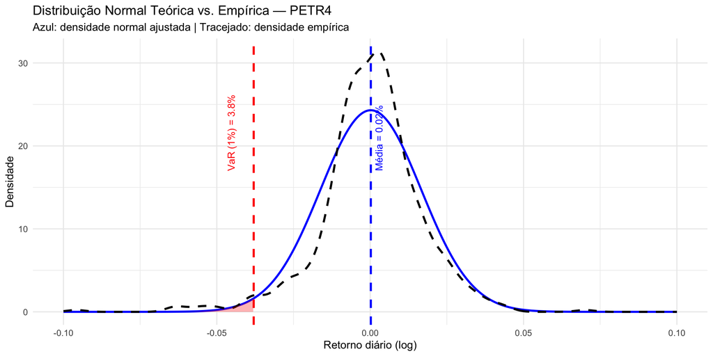

## Interpretação Visual do VaR Paramétrico

**Leitura do gráfico e considerações**

- A curva azul representa o **modelo paramétrico** assumido: neste caso, a distribuição normal ajustada aos retornos observados.
- A curva preta tracejada mostra a distribuição **empírica** dos retornos observados da ação PETR4.
- A linha vermelha tracejada marca o **quantil inferior de 1% dos retornos**, isto é, o ponto de corte da cauda esquerda segundo o modelo normal ajustado.
- A área vermelha sob a curva normal corresponde à **cauda esquerda com probabilidade $p = 1\%$**.
- Como o quantil está na escala dos retornos e costuma ser negativo, multiplicamos por $-1$ para expressar o VaR como **perda positiva**.
- Em geral, distribuições empíricas de retornos financeiros podem apresentar caudas mais pesadas e assimetria.
- Nesses casos, a hipótese de normalidade pode subestimar a frequência ou a severidade de perdas extremas.

## VaR — Método Histórico

**Método histórico ou simulação histórica**

- O método histórico estima o VaR diretamente a partir dos retornos observados.
- A ideia central é ordenar os retornos históricos do pior para o melhor e identificar o quantil empírico associado à probabilidade $p$.
- Seja $y_{(i)}$ o $i$-ésimo retorno da amostra ordenada em ordem crescente, isto é, do pior para o melhor.
- O índice usado para aproximar o quantil de nível $p$ é:

$$i = \lceil T \cdot p \rceil$$

- O VaR monetário é então calculado por:

$$VaR_t = - y_{(i)} \cdot \vartheta_t$$

em que $\vartheta_t$ é o valor financeiro da carteira.

- Neste exemplo, adotaremos diretamente o **valor total da carteira**.

## VaR — Método Histórico

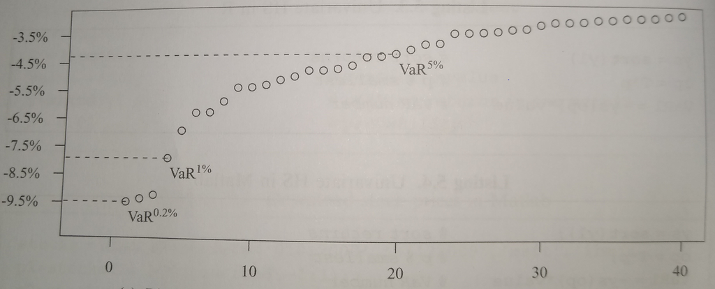

## VaR — Método Histórico

**Simulação histórica: algoritmo**

1. Escolha a probabilidade de excedência $p$, por exemplo, 1%.
2. Obtenha uma amostra de retornos históricos $y$ com tamanho $T$.
3. Ordene os retornos do menor para o maior:

$$y_{(1)} \leq y_{(2)} \leq \cdots \leq y_{(T)}$$

4. Calcule o índice:

$$i = \lceil T \cdot p \rceil$$

5. O retorno $y_{(i)}$ funciona como uma estimativa empírica do quantil inferior de ordem $p$.
6. O VaR monetário é dado por:

$$VaR_t = - y_{(i)} \cdot \vartheta_t$$

Se a carteira vale R$ 1.000 e o retorno selecionado for -3%, então o VaR será de aproximadamente R$ 30 para o horizonte considerado.

## Método Histórico

**Carteira com 1 ativo: PETR4**

- Importar os preços da ação PETR4 desde 2024-01-01 com `tq_get()`.
- Calcular os retornos logarítmicos diários da ação:

$$r_t = \log(P_t) - \log(P_{t-1})$$

- Definir o valor financeiro da carteira, $\vartheta_t$, e a probabilidade de excedência, $p$.
- Calcular o VaR usando o quantil empírico da distribuição histórica dos retornos.

## Método Histórico em R

**Estimativa do VaR Histórico — 1 Ação**

```r
# pipeline para importar os preços da ação da Petrobras,
# calcular os retornos e remover valores ausentes
precos_petrobras <- "PETR4.SA" |>
  tq_get(from = "2024-01-01") |>
  select(date, close) |>
  mutate(ret_petrobras = log(close / lag(close))) |>
  drop_na()

# Extrai vetor de retornos
ret_petrobras <- precos_petrobras |>
  pull(ret_petrobras)

# Parâmetros
valor_carteira <- 1000
p <- 0.01

# Estimação do VaR

# 1. Ordena os retornos crescentemente:
# do pior retorno para o melhor retorno
ret_petr_ord <- sort(ret_petrobras)

# 2. Encontra o índice associado ao quantil empírico de nível p
# ceiling() seleciona uma observação dentro da cauda esquerda da amostra
op <- ceiling(length(ret_petr_ord) * p)
op
```

```
[1] 6
```

```r
# 3. Retorno selecionado: quantil empírico inferior dos retornos
retorno_var_hs <- ret_petr_ord[op]
retorno_var_hs
```

```
[1] -0.055821
```

```r
# 4. VaR histórico monetário: converte retorno adverso em perda positiva
var_petr_hs <- -retorno_var_hs * valor_carteira
var_petr_hs
```

```
[1] 55.821
```

```r
# 5. VaR histórico percentual
var_percentual_petr_hs <- -retorno_var_hs * 100
var_percentual_petr_hs
```

```
[1] 5.5821
```

- Usamos `ceiling()` para selecionar uma observação localizada na cauda esquerda da amostra.
- Por exemplo, com $T = 252$ e $p = 0{,}01$, temos $T \cdot p = 2{,}52$, e o índice escolhido é $i = 3$.
- Como não estamos usando interpolação, o resultado depende da regra de arredondamento adotada.

## Visualização do VaR Histórico em R

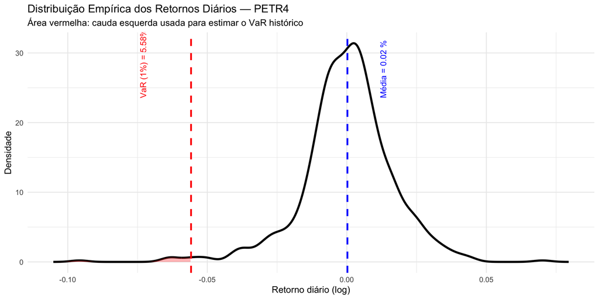

## Método Histórico

**Considerações sobre o método histórico**

- A simulação histórica é simples e não exige uma distribuição teórica para os retornos.
- Para níveis de cauda muito baixos, como 1%, são necessárias amostras relativamente longas para que haja observações suficientes na cauda.
- Com amostras curtas, a estimativa histórica do VaR pode variar bastante quando poucos retornos extremos entram ou saem da janela de estimação.
- Uma desvantagem importante é que eventos passados podem não refletir bem as condições futuras, especialmente em períodos de **quebra estrutural**.
- O método também trata os retornos passados observados como cenários relevantes para o horizonte analisado, o que pode ser inadequado quando há mudanças substanciais de regime.

## VaR — Simulação de Monte Carlo Não-Paramétrica

**Algoritmo: bootstrap histórico**

**Ideia central:** em vez de assumir uma distribuição teórica para os retornos, reamostramos os próprios retornos históricos e construímos uma distribuição simulada de cenários.

1. Defina a probabilidade de excedência do VaR, $p$, por exemplo, 1%, e o horizonte, por exemplo, 1 dia.
2. Colete a série histórica de retornos log-diários $r = (r_1, \dots, r_T)$.

**Hipótese:** a reamostragem simples trata os retornos como aproximadamente independentes e identicamente distribuídos.

3. Gere $N$ retornos simulados por **reamostragem com reposição** dos retornos históricos.

Para uma cauda de 1%, usamos um número grande de reamostragens, por exemplo $N = 10.000$, para reduzir a instabilidade da estimativa.

4. Ordene os retornos simulados:

$$r^{(s)}_{(1)} \leq r^{(s)}_{(2)} \leq \cdots \leq r^{(s)}_{(N)}$$

5. Calcule o índice do quantil:

$$i = \lceil N \cdot p \rceil$$

6. Estime o VaR monetário para o horizonte analisado:

$$VaR_t \approx -\,r^{(s)}_{(i)} \times \vartheta_t$$

em que $\vartheta_t$ é o valor da carteira.

## VaR — Simulação de Monte Carlo Não-Paramétrica

**Observação sobre retornos logarítmicos**

A fórmula

$$VaR_t \approx -\,r^{(s)}_{(i)} \times \vartheta_t$$

usa uma aproximação de primeira ordem.

Ela é adequada para retornos logarítmicos pequenos, pois:

$$e^r - 1 \approx r$$

Para converter exatamente um retorno logarítmico adverso $r < 0$ em perda monetária, usaríamos:

$$VaR_t = \vartheta_t \left(1 - e^{r^{(s)}_{(i)}}\right)$$

Nos exemplos da aula, manteremos a aproximação para preservar a simplicidade.

## Exemplo — PETR4 com Reamostragem Empírica

**Configuração do exemplo**

| Elemento | Definição |
| --- | --- |
| Ativo | PETR4 (Petrobras PN), cotações desde 01/01/2024 |
| Retorno | $r_t = \log(P_t) - \log(P_{t-1})$ — retorno log-diário |
| Valor da carteira | $\vartheta_t = R\$\,1.000$ |
| Probabilidade de excedência do VaR | $p = 1\%$ |
| Horizonte | 1 dia |
| Simulações | $N = 10.000$ |

**Interpretação do resultado:** o VaR estimado é o limiar de perda de 1 dia que será excedido com probabilidade aproximada de 1%, segundo a distribuição histórica reamostrada dos retornos da PETR4. De forma equivalente, em cerca de 99% dos cenários reamostrados, a perda não ultrapassa esse valor.

Na literatura, esses 99% também podem aparecer como **nível de confiança**. **Limitação:** a reamostragem i.i.d. ignora agrupamentos de volatilidade (*volatility clustering*). Períodos de baixa ou alta volatilidade tendem a se agrupar no tempo, o que não é capturado por este método simples.

## Código R — Estimativa do VaR por Bootstrap

```r
# Pacotes necessários
library(tidyquant)   # coleta de dados financeiros via Yahoo Finance
library(dplyr)       # manipulação de dados

# 1. Coleta e preparação dos dados

# tq_get() baixa os preços históricos diretamente do Yahoo Finance
# log(close / lag(close)): retorno logarítmico — mede variação relativa
#   em escala contínua e possui a propriedade de aditividade temporal
# drop_na(): remove a 1ª linha, que gera NA por ausência de lag
precos_petrobras <- "PETR4.SA" |>
  tq_get(from = "2024-01-01") |>
  select(date, close) |>
  mutate(ret = log(close / lag(close))) |>
  drop_na()

# vetor com os retornos observados
ret_petrobras <- precos_petrobras$ret

# 2. Definição dos parâmetros
valor_carteira <- 1000   # capital investido em reais
p  <- 0.01               # probabilidade de excedência do VaR = 1%
n  <- 10000              # número de reamostragens

# 3. Simulação — bootstrap não-paramétrico

# sample(..., replace = TRUE): sorteia retornos históricos com reposição
# Nenhuma distribuição teórica é assumida: a distribuição vem dos próprios dados
# set.seed() garante reprodutibilidade dos resultados
set.seed(123)
ret_sim <- sample(ret_petrobras, size = n, replace = TRUE)

# 4. Ordenação e localização do quantil inferior
# sort() organiza do retorno mais negativo para o mais positivo
ret_sim_ord <- sort(ret_sim)

# ceiling(n * p): índice do quantil empírico de nível p
# com n = 10.000 e p = 0,01, o índice é 100
# aproximadamente 1% dos cenários simulados ficam na cauda esquerda até esse ponto
indice_var <- ceiling(n * p)

# 5. Cálculo do VaR
# O retorno no índice é negativo; o sinal negativo o converte em perda positiva
# Aproximação para retorno log diário:
# perda ≈ -retorno * valor_carteira
# Forma exata:
# valor_carteira * (1 - exp(ret_sim_ord[indice_var]))
var_mc  <- -ret_sim_ord[indice_var] * valor_carteira
var_pct <- -ret_sim_ord[indice_var] * 100

# Resultado: limiar de perda de 1 dia que é excedido com probabilidade
# aproximada de 1%, segundo a distribuição histórica reamostrada
var_mc    # em reais
```

```
[1] 55.821
```

```r
var_pct   # em percentual
```

```
[1] 5.5821
```

## O que é o Expected Shortfall (ES)?

**Ideia central**

O **Expected Shortfall (ES)**, também chamado de **Conditional Value-at-Risk (CVaR)**, é uma medida de risco de cauda.

Enquanto o **VaR** informa o **ponto de corte** da cauda de perdas, o **ES** informa a **perda média nos casos em que esse ponto de corte é ultrapassado**.

Assim, o ES responde à seguinte pergunta:

> Quando a perda ultrapassa o VaR, qual é a perda média esperada?

O ES, portanto, complementa o VaR: ele não apenas identifica onde começa a cauda extrema, mas também resume a severidade média das perdas dentro dessa cauda.

## O que é o Expected Shortfall (ES)?

**Definição usando perdas positivas**

Seja $L$ a perda da carteira em certo horizonte de tempo, expressa como valor positivo.

Se $VaR_p$ é o VaR associado à probabilidade de excedência $p$, então  
o Expected Shortfall é definido como:

$$ES_p = E[L \mid L \geq VaR_p]$$

Ou seja, o ES é a média das perdas localizadas na cauda além do VaR.

Equivalentemente, se trabalhamos diretamente com retornos $R$ e $q_p(R)$ é o quantil inferior dos retornos, então:

$$ES_p = -E[R \mid R \leq q_p(R)]$$

A primeira forma usa **perdas positivas**. A segunda forma usa **retornos**, que são negativos na cauda esquerda.

## O que é o Expected Shortfall (ES)?

**Interpretação**

Se uma carteira tem **VaR diário de R$ 10.000 a 1%** e **ES diário de R$ 15.000 a 1%**, isso significa que:

- há aproximadamente **1% de probabilidade** de a perda diária ultrapassar R$ 10.000;
- nos dias em que essa ultrapassagem ocorre, a perda média esperada é de aproximadamente **R$ 15.000**.

Portanto, o ES é mais informativo que o VaR sobre a **severidade das perdas extremas**.

O VaR indica o **limiar** da cauda. O ES indica a **perda média dentro da cauda**.

## Estimação Empírica do ES

**Como estimamos o ES empiricamente?**

Dado um nível de probabilidade $p$, por exemplo $p = 1\%$, estimamos o **Expected Shortfall** como a média dos retornos localizados na cauda esquerda da distribuição, convertida em perda positiva.

Algoritmo histórico:

1. Ordenam-se os retornos em ordem crescente:

$$r_{(1)} \leq r_{(2)} \leq \cdots \leq r_{(T)}$$

2. Define-se o índice do VaR:

$$k = \lceil p \cdot T \rceil$$

3. O **VaR empírico**, expresso como perda positiva, é dado por:

$$VaR_p = -r_{(k)}$$

4. O **Expected Shortfall empírico**, também expresso como perda positiva, é:

$$ES_p = -\frac{1}{k} \sum_{i=1}^{k} r_{(i)}$$

Em outras palavras, o ES é a média, em valor positivo, dos retornos localizados na cauda esquerda da amostra.

## Estimação Empírica do ES

**PETR4 — Estimativa Empírica do ES**

```r
# 1. Parâmetros
p <- 0.01
valor_carteira <- 1000

# 2. Ordena os retornos da PETR4 do pior para o melhor
retornos_ordenados <- sort(ret_petrobras)

# 3. Índice associado ao quantil empírico de nível p
k <- ceiling(length(retornos_ordenados) * p)

# 4. VaR e ES empíricos na escala percentual
# VaR: ponto de corte da cauda esquerda, expresso como perda positiva
var_percentual <- -retornos_ordenados[k] * 100

# ES: média dos retornos na cauda esquerda, expressa como perda positiva
es_percentual <- -mean(retornos_ordenados[1:k]) * 100

# 5. Valores monetários
var_monetario <- var_percentual / 100 * valor_carteira
es_monetario <- es_percentual / 100 * valor_carteira

# Resultados
var_monetario
```

```
[1] 55.821
```

```r
es_monetario
```

```
[1] 66.437
```

## Visualização do Expected Shortfall (ES)

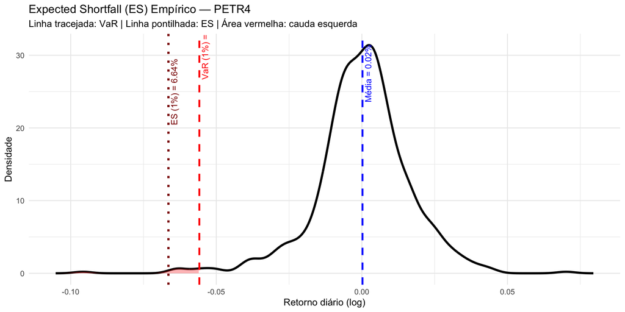

## Expected Shortfall - Interpretação Visual

**VaR vs. ES**

- No gráfico de densidade dos retornos, o VaR é representado por uma linha vertical tracejada vermelha.
- Essa linha marca o quantil inferior de 1% dos retornos, isto é, o ponto de corte da cauda esquerda.
- O Expected Shortfall aparece como uma linha pontilhada mais à esquerda, pois representa a média dos retornos localizados nessa cauda.
- No eixo dos retornos, o ES aparece mais à esquerda do que o VaR, pois é calculado a partir dos retornos mais negativos.
- Quando expressos como perdas positivas, o ES é maior ou igual ao VaR.
- Por isso, o ES informa melhor a severidade das perdas extremas.

## Considerações Finais

**Por que o ES é mais informativo que o VaR?**

- O VaR informa o ponto de corte da cauda de perdas.
- O ES informa a perda média quando esse ponto de corte é ultrapassado.
- Por isso, o ES leva em conta a severidade das perdas extremas, não apenas a posição do quantil.
- Além disso, o ES é teoricamente mais adequado como medida de risco de cauda, pois satisfaz propriedades de coerência, como a subaditividade.
- No arcabouço FRTB, o ES substitui o VaR na abordagem de modelos internos para cálculo de capital regulatório de risco de mercado.
- Na prática, VaR e ES podem ser usados de forma complementar: o VaR indica o limiar da cauda, enquanto o ES resume a severidade média dentro dela.

# Carteria com 3 Ações

## Retorno da Carteira com 3 Ativos

**Retorno de uma Carteira**

- Seja uma carteira com três ativos, com pesos $(w\_1, w\_2, w\_3)$ associados a cada ação:

| Ação | Ticker | Peso na Carteira ($w_i$) |
| --- | --- | --- |
| Petrobrás | PETR4.SA | $w_1$ |
| Magazine Luiza | MGLU3.SA | $w_2$ |
| Itaú Unibanco | ITUB4.SA | $w_3$ |

- Os retornos diários dos ativos no tempo $t$ são $(r_{1,t}, r_{2,t}, r_{3,t})$.
- O retorno da carteira no tempo $t$** é a média ponderada dos retornos:

$$r_{c,t} = w_1 \cdot r_{1,t} + w_2 \cdot r_{2,t} + w_3 \cdot r_{3,t}$$

- Em notação vetorial:

$$r_{c,t} = \mathbf{w}^\top \mathbf{r}_t
\quad \text{onde }
\mathbf{w} =
\begin{bmatrix}
w_1 \\ w_2 \\ w_3
\end{bmatrix},
\quad
\mathbf{r}_t =
\begin{bmatrix}
r_{1,t} \\ r_{2,t} \\ r_{3,t}
\end{bmatrix}$$

## Variância e Volatilidade da Carteira

**Variância da Carteira**

- A variância dos retornos da carteira, $\text{Var}(r_c)$, é dada por:

$$\text{Var}(r_c) = \mathbf{w}^\top \boldsymbol{\Sigma} \mathbf{w}$$

Onde:

- $\mathbf{w}$ é o vetor de pesos da carteira;
- $\boldsymbol{\Sigma}$ é a matriz de covariância dos retornos dos ativos:

$$\boldsymbol{\Sigma} =
\begin{bmatrix}
\sigma_1^2 & \sigma_{12} & \sigma_{13} \\
\sigma_{21} & \sigma_2^2 & \sigma_{23} \\
\sigma_{31} & \sigma_{32} & \sigma_3^2
\end{bmatrix}$$

- O **desvio-padrão da carteira** é:

$$\sigma_c = \sqrt{\text{Var}(r_c)}$$

- A variância incorpora não apenas a **volatilidade individual**, mas também a **correlação entre os ativos** — capturando o benefício da **diversificação**.

## Retornos da Carteira em R

**Implementação em R**

```r
# Importa as séries de preços das ações
serie_precos <- c("PETR4.SA", "MGLU3.SA", "ITUB4.SA") %>%
  tq_get(from = "2024-01-01") %>%
  select(symbol, date, close) %>%
  pivot_wider(names_from = symbol, values_from = close) %>%
  rename(dia = date,
         petr4 = PETR4.SA,
         mglu3 = MGLU3.SA,
         itub4 = ITUB4.SA)

# Calcula retornos logarítmicos
retornos <- serie_precos %>%
  mutate(
    ret_petr4 = log(petr4 / lag(petr4)),
    ret_mglu3 = log(mglu3 / lag(mglu3)),
    ret_itub4 = log(itub4 / lag(itub4))
  ) %>%
  drop_na()

# Define os pesos
pesos <- c(0.4, 0.3, 0.3)  # exemplo: 40% PETR4, 30% MGLU3, 30% ITUB4

# Calcula o retorno da carteira
retornos <- retornos %>%
  mutate(
    ret_carteira = pesos[1] * ret_petr4 +
                   pesos[2] * ret_mglu3 +
                   pesos[3] * ret_itub4
  )

# dimensão do retorno da carteira
dim(retornos$ret_carteira)

# exibie as primeiras linhas
head(retornos$ret_carteira)
```

[output not shown]

## VaR Histórico da Carteira

**Estimativa do VaR — Método Histórico**

```r
# Parâmetros
p <- 0.01
valor_carteira <- 1000

# Ordena retornos da carteira
ret_ordenado <- sort(retornos$ret_carteira)

# Índice do quantil
k <- ceiling(length(ret_ordenado) * p)

# VaR percentual e monetário
var_percentual <- -ret_ordenado[k] * 100
var_monetario <- -ret_ordenado[k] * valor_carteira

var_percentual
var_monetario
```

[output not shown]

- O **VaR histórico** é a perda mínima entre as **1% piores perdas históricas**.
- Conservador por natureza — não depende de suposições paramétricas.

## Estimativa do Expected Shortfall (ES)

**Estimativa do ES — Média Condicional**

```r
# Expected Shortfall (ES)
es_percentual <- -mean(ret_ordenado[1:k]) * 100
es_monetario <- -mean(ret_ordenado[1:k]) * valor_carteira

es_percentual
```

[output not shown]

```r
es_monetario
```

[output not shown]

- O **Expected Shortfall** é a **média das perdas mais severas**, ou seja:

$$ES = - \frac{1}{k} \sum_{i=1}^{k} r^{(i)}$$

- O ES sempre **excede (em magnitude)** o VaR — é mais conservador.

# Exercícios

## Exercício 1

**VaR e Expected Shortfall histórico para uma ação**

Considere uma carteira formada apenas pela ação **PETR4.SA**.

Usando a linguagem R, faça o que se pede:

1. Importe os preços diários da ação PETR4.SA a partir de `2024-01-01`.
2. Calcule os retornos logarítmicos diários da ação, definidos por:

$$r_t = \log\left(\frac{P_t}{P_{t-1}}\right)$$

3. Considere que o valor financeiro da carteira é de **R$ 10.000,00** e que a probabilidade de excedência é $p = 1\%$.
4. Calcule o **VaR histórico diário** da carteira, em percentual e em reais.
5. Calcule o **Expected Shortfall histórico diário** da carteira, em percentual e em reais.
6. Interprete os resultados obtidos, explicando a diferença entre VaR e Expected Shortfall.

## Exercício 2

**Enunciado: VaR e Expected Shortfall histórico para uma carteira com três ações**

Considere uma carteira formada por três ações negociadas na B3:

| Ação | Ticker | Peso na carteira |
| --- | --- | --- |
| Petrobras PN | PETR4.SA | 40% |
| Magazine Luiza | MGLU3.SA | 30% |
| Itaú Unibanco PN | ITUB4.SA | 30% |

Usando a linguagem R, faça o que se pede:

1. Importe os preços diários das três ações a partir de `2024-01-01`.
2. Calcule os retornos logarítmicos diários de cada ação.
3. Calcule o retorno diário da carteira usando a média ponderada dos retornos:

$$r_{c,t} = 0,40r_{\text{PETR4},t} + 0,30r_{\text{MGLU3},t} 0,30r_{\text{ITUB4},t}$$

4. Considere que o valor financeiro da carteira é de **R$ 50.000,00** e que a probabilidade de excedência é $p = 1\%$.
5. Calcule o **VaR histórico diário** da carteira, em percentual e em reais.
6. Calcule o **Expected Shortfall histórico diário** da carteira, em percentual e em reais.
7. Interprete os resultados obtidos e explique por que o ES tende a ser maior que o VaR.